# Main_RMD

## Data Wrangling

```r
knoedler_usd <- knoedler %>%
  filter(price_currency == "dollars") %>%
  mutate(price_amount = adjust_for_inflation(price_amount, sale_date_year, to_date = 2020, country = "US"))
```

```
## Retrieving countries data
```

```
## Generating URL to request all 299 results
## Retrieving inflation data for US
## Generating URL to request all 61 results
```

```r
knoedler_pounds <- knoedler %>%
  filter(price_currency == "pounds") %>%
  mutate(price_amount = adjust_for_inflation(price_amount, sale_date_year, to_date = 2020, country = "GB"))
```

```
## Retrieving countries data
```

```
## Generating URL to request all 299 results
## Retrieving inflation data for GB
## Generating URL to request all 61 results
```

```r
#step1 - remove everything that isn't a number, a slash, or an x|X
knoedler_dimensions_usd <- knoedler_usd %>%
  mutate(dims_cleaned = str_replace_all(dimensions, "\\[|\\]", "")) %>%
  filter(!is.na(dimensions)) %>%
  mutate(dim1 = str_split(dims_cleaned, "x|X", simplify = TRUE)[,1],
         dim2 = str_split(dims_cleaned, "x|X", simplify = TRUE)[,2]) %>%
  mutate(dim1 = str_replace_all(dim1, "\\d/\\d", ""),
         dim2 = str_replace_all(dim2, "\\d/\\d", "")) %>%
  mutate(dim1 = str_replace_all(dim1, "[:alpha:]|[:punct:]", ""),
         dim2 = str_replace_all(dim2, "[:alpha:]|[:punct:]", "")) %>%
  mutate(dim1 = as.numeric(str_extract(dim1, "\\d\\d\\d|\\d\\d|\\d")),
         dim2 = as.numeric(str_extract(dim2, "\\d\\d\\d|\\d\\d|\\d"))) %>%
  mutate(inches_squared = dim1 * dim2)
knoedler_dimensions_usd <- knoedler_dimensions_usd %>%
  mutate(price_per_sqin = price_amount/inches_squared)

knoedler_dimensions_pounds <- knoedler_pounds %>%
  mutate(dims_cleaned = str_replace_all(dimensions, "\\[|\\]", "")) %>%
  filter(!is.na(dimensions)) %>%
  mutate(dim1 = str_split(dims_cleaned, "x|X", simplify = TRUE)[,1],
         dim2 = str_split(dims_cleaned, "x|X", simplify = TRUE)[,2]) %>%
  mutate(dim1 = str_replace_all(dim1, "\\d/\\d", ""),
         dim2 = str_replace_all(dim2, "\\d/\\d", "")) %>%
  mutate(dim1 = str_replace_all(dim1, "[:alpha:]|[:punct:]", ""),
         dim2 = str_replace_all(dim2, "[:alpha:]|[:punct:]", "")) %>%
  mutate(dim1 = as.numeric(str_extract(dim1, "\\d\\d\\d|\\d\\d|\\d")),
         dim2 = as.numeric(str_extract(dim2, "\\d\\d\\d|\\d\\d|\\d"))) %>%
  mutate(inches_squared = dim1 * dim2)
knoedler_dimensions_pounds <- knoedler_dimensions_pounds %>%
  mutate(price_per_sqin = price_amount/inches_squared)

knoedler_dimensions_combined <- full_join(knoedler_dimensions_usd, knoedler_dimensions_pounds, by = c("dim1", "dim2", "inches_squared", "sale_date_year", "subject"))
View(knoedler_dimensions_combined)
```

## Plots

```r
theme(text = element_text(family = "serif"))
```

[output not shown]

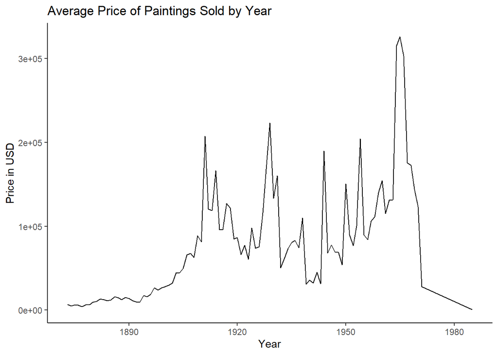

```r
years_average_prices_usd <- knoedler_usd %>%
  filter(!is.na(sale_date_year), !is.na(price_amount)) %>%
  group_by(sale_date_year) %>%
  summarise(average_price = mean(price_amount))

years_average_prices_pounds <- knoedler_pounds %>%
  filter(!is.na(sale_date_year), !is.na(price_amount)) %>%
  group_by(sale_date_year) %>%
  summarise(average_price = mean(price_amount))

average_price_by_year_usd <- ggplot(data = years_average_prices_usd) +
  geom_line(aes(x = sale_date_year, y = average_price)) +
  theme_classic() +
  labs(title = "Average Price of Paintings Sold by Year",
       x = "Year",
       y = "Price in USD")
average_price_by_year_usd
```

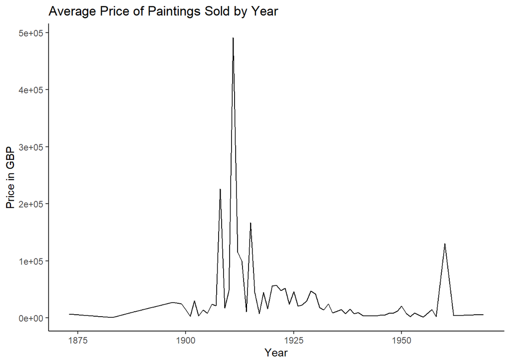

```r
average_price_by_year_pounds <- ggplot(data = years_average_prices_pounds) +
  geom_line(aes(x = sale_date_year, y = average_price)) +
  theme_classic() +
  labs(title = "Average Price of Paintings Sold by Year",
       x = "Year",
       y = "Price in GBP")
average_price_by_year_pounds
```

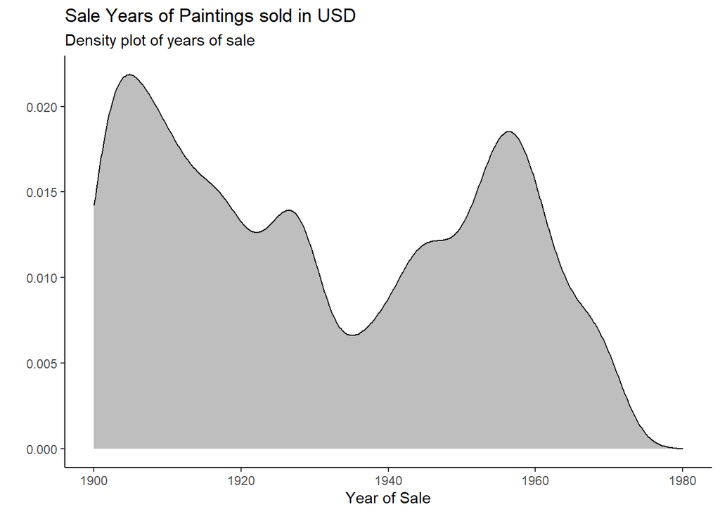

```r
year_density_usd <- ggplot(data = knoedler_usd, aes(x = sale_date_year)) +
  scale_x_continuous(limits = c(1900, 1980)) +
  geom_density(fill = "gray") +
  theme_classic() +
  labs(title = "Sale Years of Paintings sold in USD",
       subtitle = "Density plot of years of sale", x = "Year of Sale",
       y = "")
year_density_usd
```

```r
year_density_pounds <- ggplot(data = knoedler_pounds, aes(x = sale_date_year)) +
  scale_x_continuous(limits = c(1900, 1980)) +
  geom_density(fill = "gray") +
  theme_classic() +
  labs(title = "Sale Years of Paintings sold in GBP",
       subtitle = "Density plot of years of sale", x = "Year of Sale",
       y = "")
```

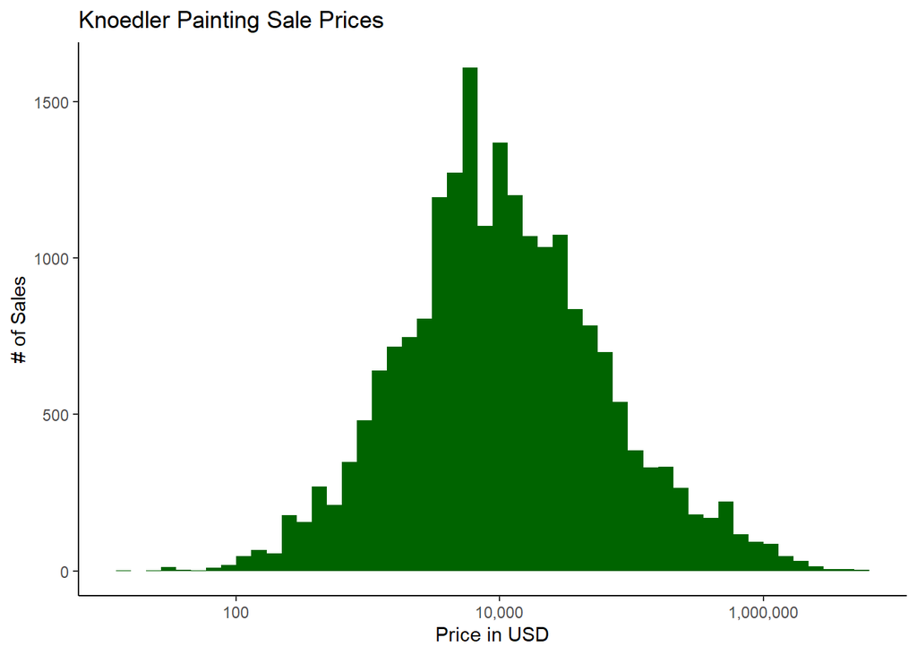

```r
 price_histogram_logged_usd <- knoedler_usd %>%
  ggplot(aes(x = price_amount, color = price_amount)) +
  geom_histogram(bins = 50, fill = "darkgreen") +
  scale_x_log10(label = comma) +
  labs(title = "Knoedler Painting Sale Prices",
       x = "Price in USD",
       y = "# of Sales") +
  theme_classic()

 price_histogram_nonlogged_usd <- knoedler_usd %>%
  ggplot(aes(x = price_amount, color = price_amount)) +
  geom_histogram(bins = 50, fill = "darkgreen") +
  scale_x_continuous(limits = c(0, 250000),label = comma) +
  labs(title = "Knoedler Painting Sale Prices",
       x = "Price in USD",
       y = "# of Sales") +
  theme_classic()

price_histogram_logged_usd
```

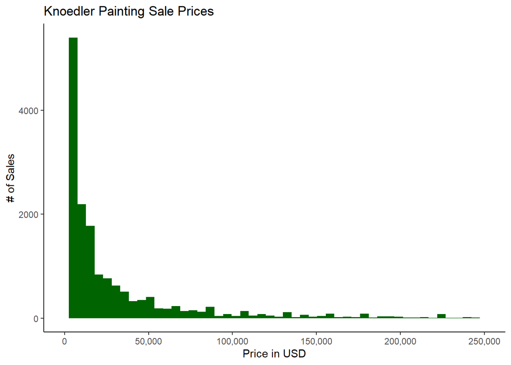

```r
price_histogram_nonlogged_usd
```

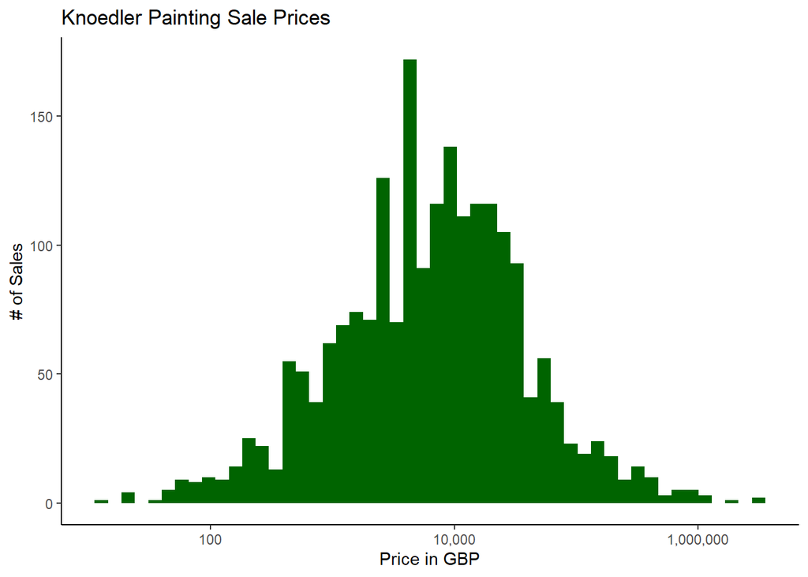

```r
 price_histogram_logged_pounds <- knoedler_pounds %>%
  ggplot(aes(x = price_amount, color = price_amount)) +
  geom_histogram(bins = 50, fill = "darkgreen") +
  scale_x_log10(label = comma) +
  labs(title = "Knoedler Painting Sale Prices",
       x = "Price in GBP",
       y = "# of Sales") +
  theme_classic()

 price_histogram_nonlogged_pounds <- knoedler_pounds %>%
  ggplot(aes(x = price_amount, color = price_amount)) +
  geom_histogram(bins = 50, fill = "darkgreen") +
  scale_x_continuous(limits = c(0, 250000),label = comma) +
  labs(title = "Knoedler Painting Sale Prices",
       x = "Price in GBP",
       y = "# of Sales") +
  theme_classic()

price_histogram_logged_pounds
```

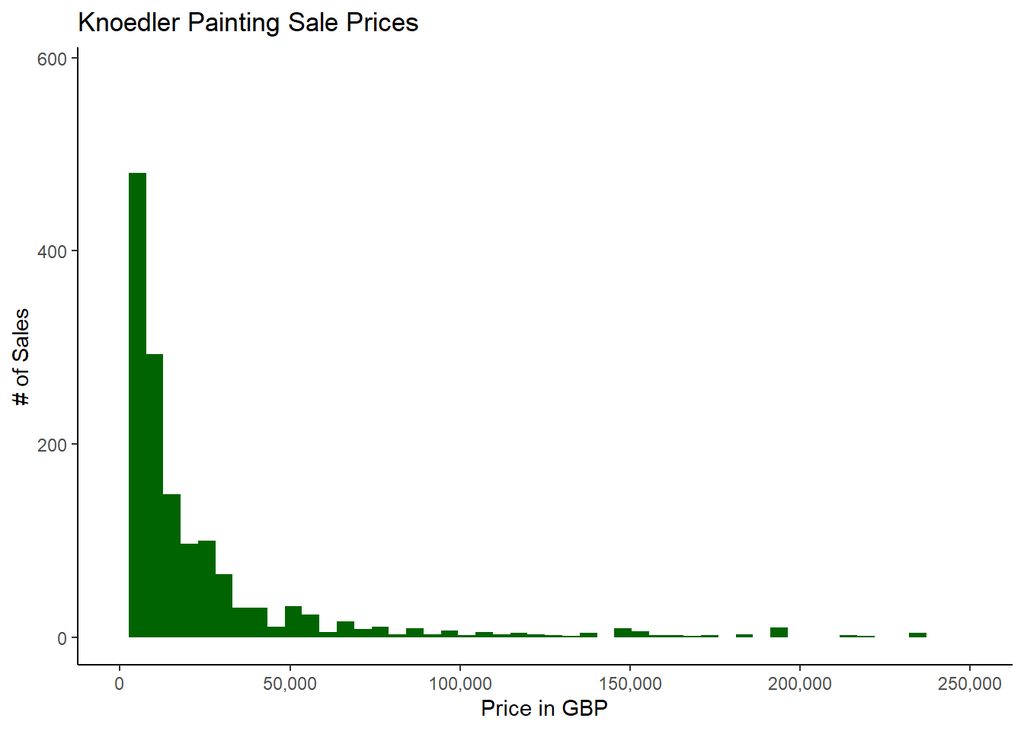

```r
price_histogram_nonlogged_pounds
```

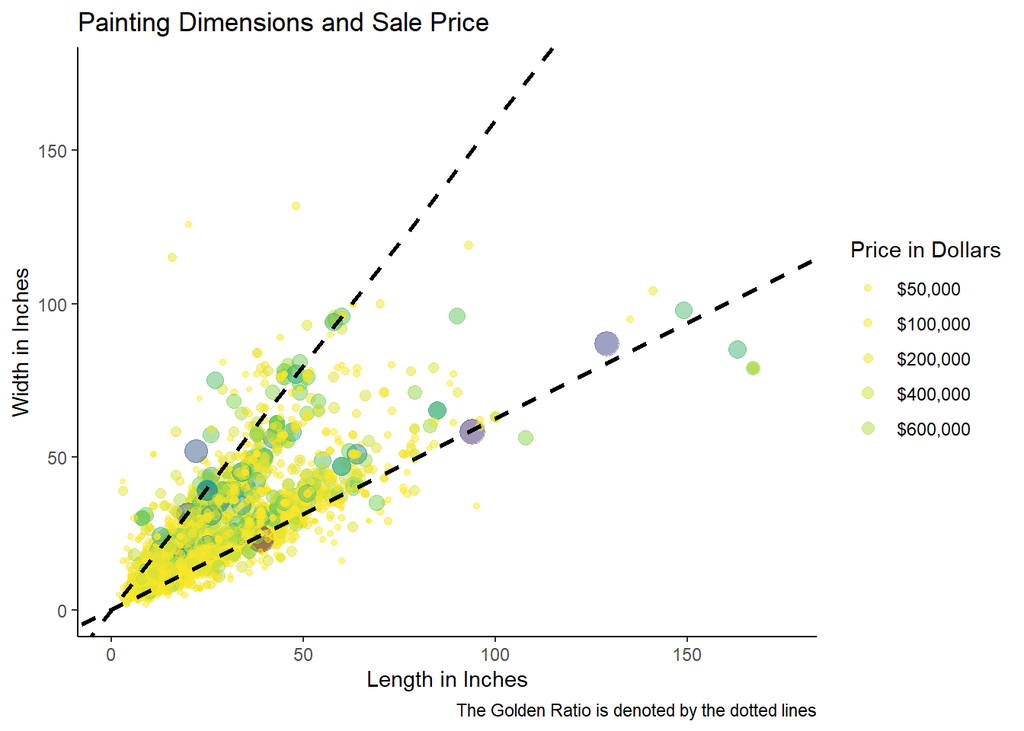

```r
golden_ratio_scatter_usd <- knoedler_dimensions_usd %>%
ggplot() +
  theme_classic() +
  geom_point(aes(x = dim1, y = dim2, size = price_amount, color = price_amount), alpha = .5) +
  scale_color_viridis_c(direction = -1, labels = c("$50,000","$100,000","$200,000","$400,000","$600,000"), breaks = c(50000, 100000, 200000, 400000, 600000), begin = 0, end = 1) +
  scale_size_continuous(labels = c("$50,000", "$100,000","$200,000","$400,000","$600,000"), breaks = c(50000 ,100000, 200000, 400000, 600000)) +
  geom_abline(slope = 1.6, intercept = 0, color = "black", size = 1, linetype = 2) +
  geom_abline(slope = 1/1.6, intercept = 0, color = "black", size = 1, linetype = 2) +
  coord_cartesian(xlim = c(0, 175),
                  ylim = c(0, 175)) +
  guides(color = guide_legend(), size = guide_legend()) +
  labs(title = "Painting Dimensions and Sale Price",
       x = "Length in Inches",
       y = "Width in Inches",
       color = "Price in Dollars",
       size = "Price in Dollars",
       caption = "The Golden Ratio is denoted by the dotted lines")

golden_ratio_scatter_pounds <- knoedler_dimensions_pounds %>%
ggplot() +
  theme_classic() +
  geom_point(aes(x = dim1, y = dim2, size = price_amount, color = price_amount), alpha = .5) +
  scale_color_viridis_c(direction = -1, labels = c("$50,000","$100,000","$200,000","$400,000","$600,000"), breaks = c(50000, 100000, 200000, 400000, 600000), begin = 0, end = 1) +
  scale_size_continuous(labels = c("$50,000", "$100,000","$200,000","$400,000","$600,000"), breaks = c(50000 ,100000, 200000, 400000, 600000)) +
  geom_abline(slope = 1.6, intercept = 0, color = "black", size = 1, linetype = 2) +
  geom_abline(slope = 1/1.6, intercept = 0, color = "black", size = 1, linetype = 2) +
  coord_cartesian(xlim = c(0, 175),
                  ylim = c(0, 175)) +
  guides(color = guide_legend(), size = guide_legend()) +
  labs(title = "Painting Dimensions and Sale Price",
       x = "Length in Inches",
       y = "Width in Inches",
       color = "Price in GBP",
       size = "Price in GBP",
       caption = "The Golden Ratio is denoted by the dotted lines")


subject_size_boxplots <- knoedler_dimensions_combined %>%
  filter(!is.na(subject)) %>%
ggplot() +
  geom_boxplot(aes(x = inches_squared, y = fct_reorder(subject, inches_squared, .fun = median), color = subject)) +
  scale_x_log10() +
  theme_classic() +
  labs(title = "Size of Paintings by Subject",
       caption = "Painting Sizes & Subjects from M. Knoedler & Co. Stock Books",
       x = "Size in Inches Squared",
       y = "Subject") +
  scale_color_discrete_qualitative() +
  theme(legend.position = "none")

subject_price_bars_usd <- knoedler_usd %>%
  filter(!is.na(subject), !is.na(price_amount)) %>%
  group_by(subject) %>%
  summarise(mean_price = mean(price_amount)) %>%
  ggplot(aes(y = fct_reorder(subject, mean_price), x = mean_price, fill = subject)) +
  theme_classic() +
  geom_col() +
  scale_x_sqrt(label = comma) +
  scale_fill_discrete_qualitative() +
  theme(legend.position = "none") +
  labs(title = "Mean Painting Sales Price by Subject",
       x = "Mean Painting Price in USD",
       y = "Subject")

subject_price_bars_pounds <- knoedler_pounds %>%
  filter(!is.na(subject), !is.na(price_amount)) %>%
  group_by(subject) %>%
  summarise(mean_price = mean(price_amount)) %>%
  ggplot(aes(y = fct_reorder(subject, mean_price), x = mean_price, fill = subject)) +
  theme_classic() +
  geom_col() +
  scale_x_sqrt(label = comma) +
  scale_fill_discrete_qualitative() +
  theme(legend.position = "none") +
  labs(title = "Mean Painting Sales Price by Subject",
       x = "Mean Painting Price in GBP",
       y = "Subject")



golden_ratio_scatter_usd
```

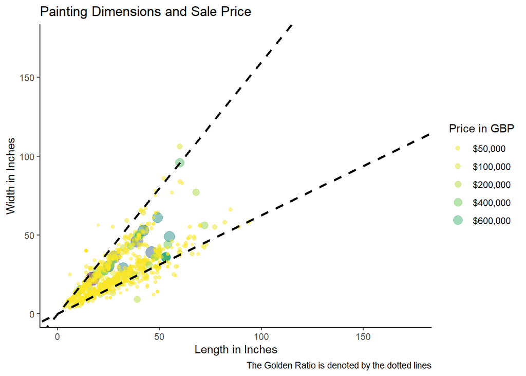

```r
golden_ratio_scatter_pounds
```

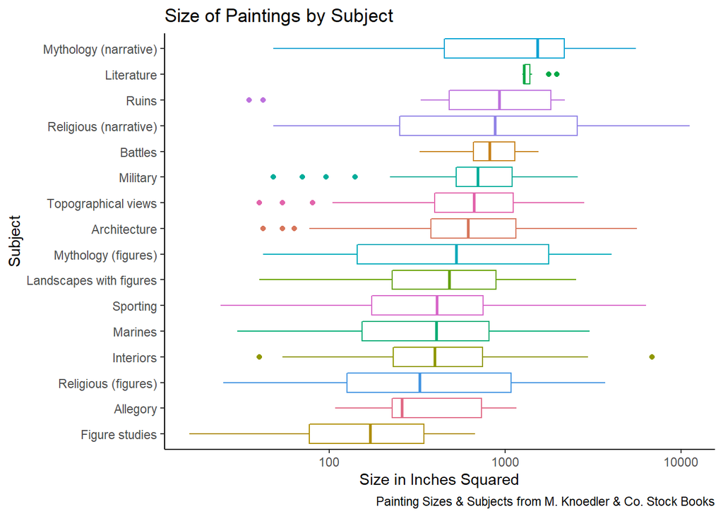

```r
subject_size_boxplots
```

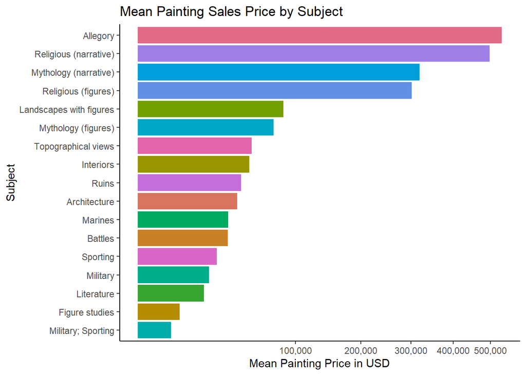

```r
subject_price_bars_usd
```

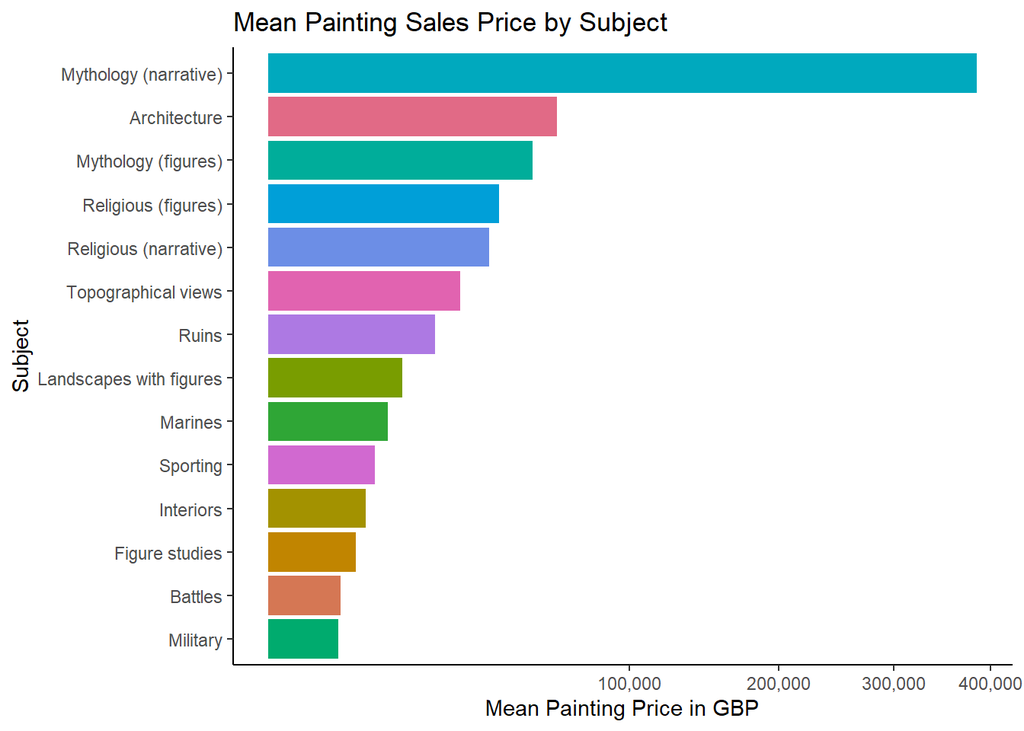

```r
subject_price_bars_pounds
```

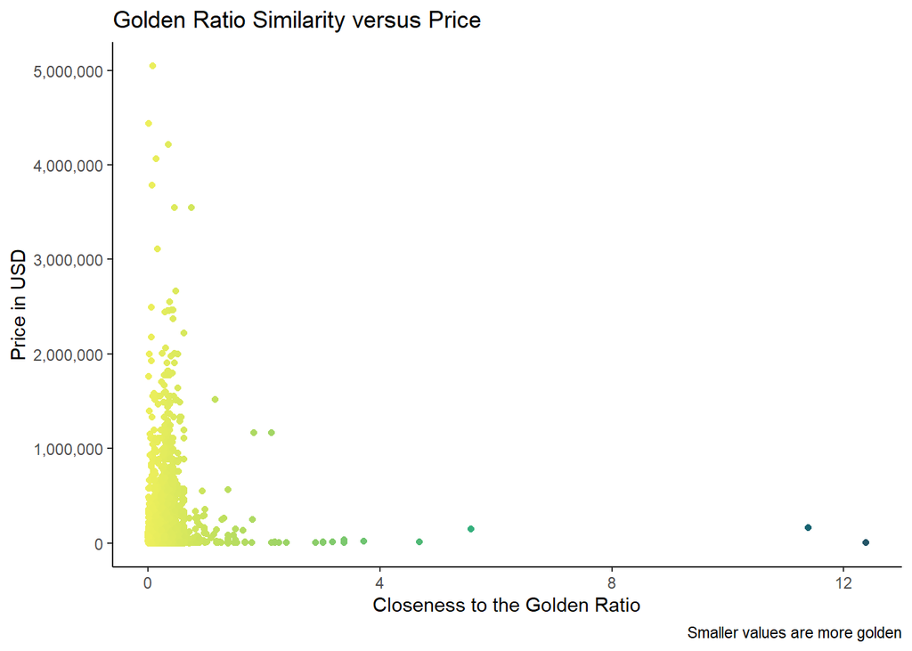

```r
#golden ratio closeness vs sale price
#raw size vs price

golden_ratio_plot <- knoedler_dimensions_usd %>%
  mutate(ratio1 = dim1/dim2,
         ratio2 = dim2/dim1,
         bigratio = if_else(ratio1 >= ratio2, ratio1, ratio2),
         difference = abs(1.618 - bigratio)) %>%
  select(price_amount, difference) %>%
  filter(!is.na(price_amount)) %>%
  ggplot(aes(x = difference, y = price_amount)) +
  theme_classic() +
  geom_point(aes(color = difference)) +
  scale_color_continuous_sequential(palette = "ag_GrnYl") +
  scale_y_continuous(label = comma) +
  labs(title = "Golden Ratio Similarity versus Price",
       x = "Closeness to the Golden Ratio",
       y = "Price in USD",
       caption = "Smaller values are more golden") +
  theme(legend.position = "none")


frequency_subject_plot <- knoedler_dimensions_usd %>%
  filter(!is.na(subject)) %>%
  count(subject) %>%
  ggplot(aes(x = n, y = fct_reorder(subject, n), fill = n)) +
  geom_col() +
  scale_fill_continuous_qualitative() +
  theme_classic() +
  theme(legend.position = "none") +
  labs(x = "Frequency",
       y = "Subject",
       title = "Frequency of Knoedler Subjects",
       caption = "Data from M. Knoedler & Co Stockbooks") +
  geom_text(aes(x = n + 17, y = fct_reorder(subject, n), label = as.character(n)))
golden_ratio_plot
```

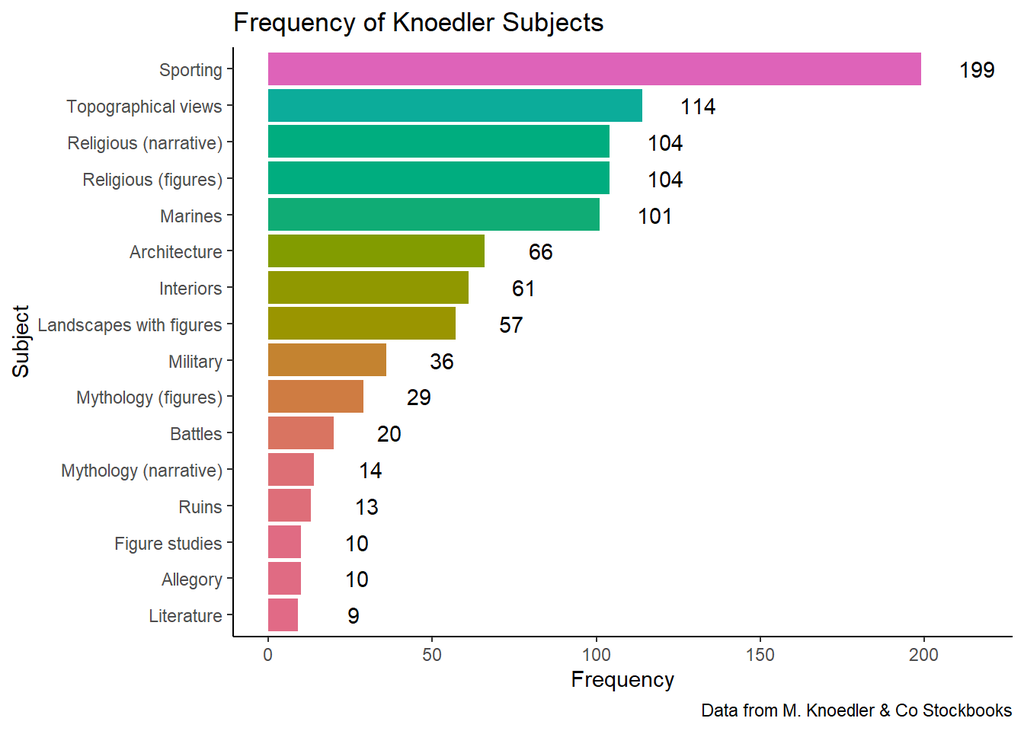

```r
frequency_subject_plot
```

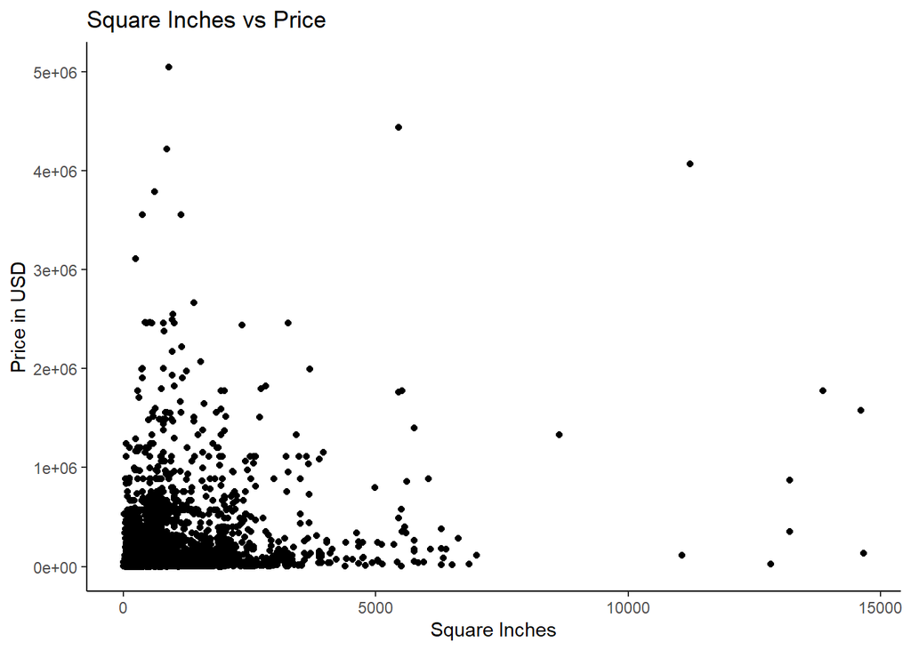

```r
price_square_inches<- ggplot(data = knoedler_dimensions_usd,
       aes(y = price_amount,
           x = inches_squared)) +
  geom_point() +
  theme_classic() +
  labs(title = "Square Inches vs Price",
       x = "Square Inches",
       y = "Price in USD")
price_square_inches
```

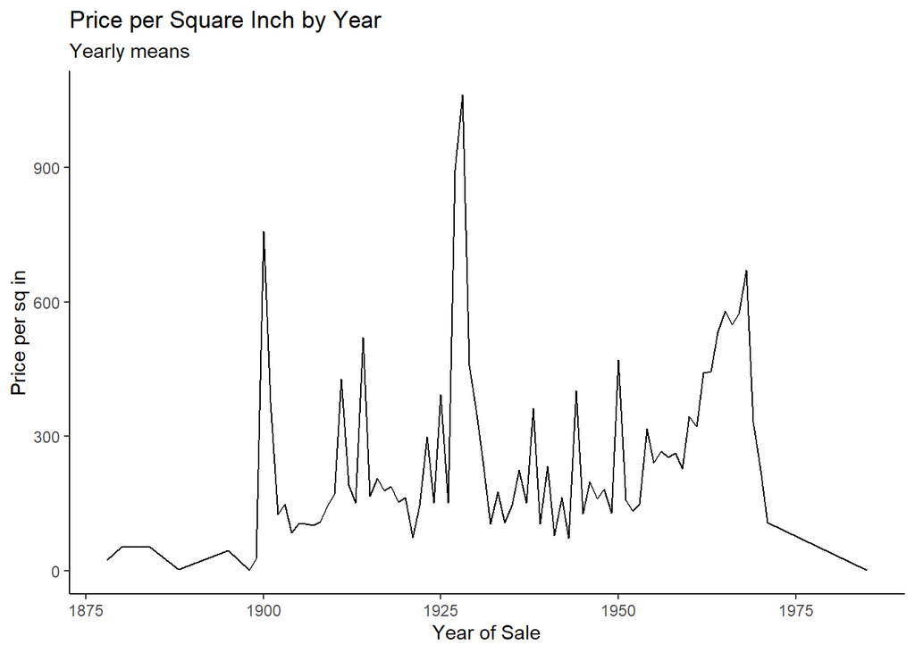

```r
price_per_yearmeans <- knoedler_dimensions_usd %>%
  filter(!is.na(sale_date_year), !is.na(price_per_sqin)) %>%
  group_by(sale_date_year) %>%
  summarise(avg_price_per_sqin = mean(price_per_sqin))

price_per_sq <- ggplot(data = price_per_yearmeans,
                       aes(y = avg_price_per_sqin, x = sale_date_year)) +
  geom_line() +
  theme_classic() +
  labs(title = "Price per Square Inch by Year",
       subtitle = "Yearly means",
       x = "Year of Sale",
       y = "Price per sq in")
price_per_sq
```

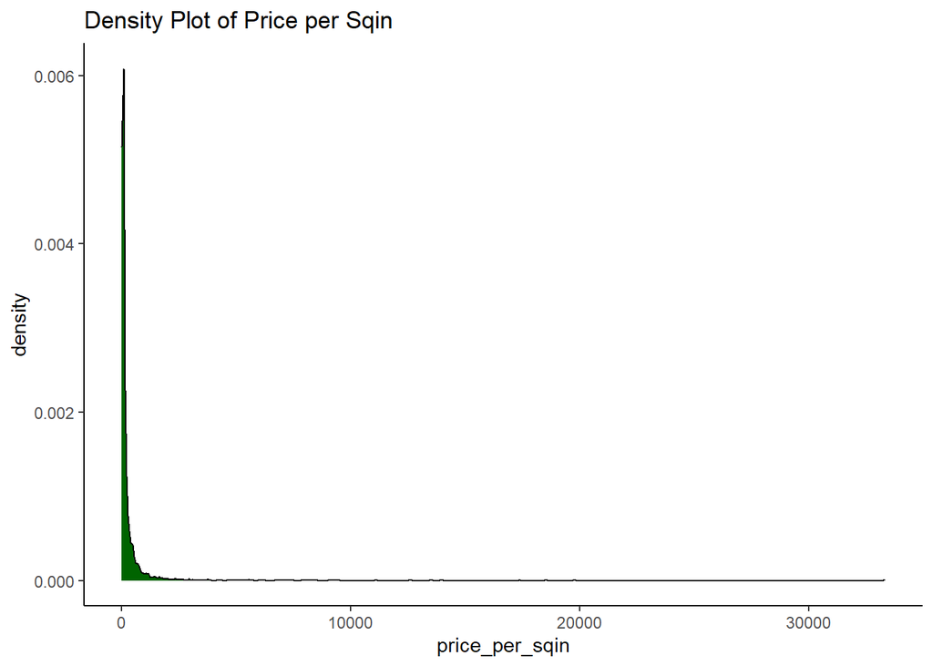

```r
sqin_density <- ggplot(data = knoedler_dimensions_usd) +
  geom_density(aes(x = price_per_sqin), fill = "darkgreen") +
  theme_classic() +
  labs(title = "Density Plot of Price per Sqin")
sqin_density
```

```r
knoedler_dimensions_usd <- knoedler_dimensions_usd %>%
  mutate(nationality_1 = fct_relevel(nationality_1, "American"))
basic_lm <- lm(price_amount ~ nationality_1 + sale_date_year + subject + genre + inches_squared,
             data = knoedler_dimensions_usd)
summary(basic_lm)
```

```
##
## Call:
## lm(formula = price_amount ~ nationality_1 + sale_date_year +
##     subject + genre + inches_squared, data = knoedler_dimensions_usd)
##
## Residuals:
##      Min       1Q   Median       3Q      Max
## -1257371  -116235   -11763    53930  3211529
##
## Coefficients: (1 not defined because of singularities)
##                                   Estimate Std. Error t value Pr(>|t|)
## (Intercept)                     -3.937e+06  1.328e+06  -2.964 0.003117 **
## nationality_1Belgian             8.078e+04  1.339e+05   0.603 0.546512
## nationality_1Bohemian            1.354e+06  3.165e+05   4.278 2.09e-05 ***
## nationality_1British             9.822e+03  4.004e+04   0.245 0.806283
## nationality_1Danish             -7.612e+04  3.130e+05  -0.243 0.807929
## nationality_1Dutch               1.825e+05  5.196e+04   3.513 0.000466 ***
## nationality_1Dutch and American -2.637e+04  3.144e+05  -0.084 0.933166
## nationality_1Flemish             3.936e+05  1.056e+05   3.727 0.000206 ***
## nationality_1French              6.559e+04  3.625e+04   1.809 0.070721 .
## nationality_1French and Italian -4.768e+04  3.133e+05  -0.152 0.879063
## nationality_1German              4.912e+04  9.259e+04   0.531 0.595870
## nationality_1Greek              -3.474e+05  2.310e+05  -1.504 0.132974
## nationality_1Greek and Spanish   9.280e+05  9.680e+04   9.587  < 2e-16 ***
## nationality_1Italian             1.461e+05  4.457e+04   3.277 0.001090 **
## nationality_1Mexican            -5.897e+05  3.297e+05  -1.789 0.073990 .
## nationality_1Netherlandish       3.604e+04  7.202e+04   0.500 0.616868
## nationality_1Polish              2.550e+04  1.692e+05   0.151 0.880231
## nationality_1Portuguese         -1.057e+05  3.184e+05  -0.332 0.739998
## nationality_1Russian             7.647e+04  1.629e+05   0.470 0.638796
## nationality_1Spanish             3.242e+05  5.980e+04   5.422 7.59e-08 ***
## nationality_1Swedish             2.121e+04  3.282e+05   0.065 0.948468
## nationality_1Unknown            -5.949e+04  1.156e+05  -0.515 0.606838
## nationality_1Uruguayan          -9.626e+04  3.182e+05  -0.303 0.762298
## sale_date_year                   2.261e+03  6.762e+02   3.344 0.000861 ***
## subjectArchitecture             -5.942e+05  1.795e+05  -3.311 0.000967 ***
## subjectBattles                  -5.181e+05  1.285e+05  -4.032 6.01e-05 ***
## subjectFigure studies           -4.759e+05  1.503e+05  -3.167 0.001595 **
## subjectInteriors                -5.348e+05  1.135e+05  -4.712 2.85e-06 ***
## subjectLandscapes with figures  -4.996e+05  1.810e+05  -2.760 0.005890 **
## subjectLiterature               -6.394e+05  1.509e+05  -4.236 2.51e-05 ***
## subjectMarines                  -5.645e+05  1.791e+05  -3.153 0.001672 **
## subjectMilitary                 -5.325e+05  1.226e+05  -4.343 1.57e-05 ***
## subjectMythology (figures)      -4.513e+05  1.228e+05  -3.675 0.000252 ***
## subjectMythology (narrative)    -2.840e+05  1.367e+05  -2.078 0.038037 *
## subjectReligious (figures)      -3.182e+05  1.097e+05  -2.902 0.003803 **
## subjectReligious (narrative)    -3.373e+05  1.105e+05  -3.051 0.002345 **
## subjectRuins                    -6.393e+05  1.955e+05  -3.269 0.001120 **
## subjectSporting                 -5.212e+05  1.115e+05  -4.673 3.43e-06 ***
## subjectTopographical views      -5.736e+05  1.760e+05  -3.258 0.001162 **
## genreHistory                            NA         NA      NA       NA
## genreLandscape                   3.510e+04  1.406e+05   0.250 0.802857
## genrePortrait                   -2.207e+05  3.178e+05  -0.694 0.487562
## inches_squared                   1.284e+02  1.224e+01  10.487  < 2e-16 ***
## ---
## Signif. codes:  0 '***' 0.001 '**' 0.01 '*' 0.05 '.' 0.1 ' ' 1
##
## Residual standard error: 310500 on 898 degrees of freedom
##   (6169 observations deleted due to missingness)
## Multiple R-squared:  0.4247, Adjusted R-squared:  0.3985
## F-statistic: 16.17 on 41 and 898 DF,  p-value: < 2.2e-16
```

```r
arrange(head(tidy(basic_lm), 23), p.value)
```

```
## # A tibble: 23 x 5
##    term                            estimate std.error statistic  p.value
##    <chr>                              <dbl>     <dbl>     <dbl>    <dbl>
##  1 nationality_1Greek and Spanish   928027.    96796.      9.59 8.58e-21
##  2 nationality_1Spanish             324239.    59804.      5.42 7.59e- 8
##  3 nationality_1Bohemian           1354189.   316538.      4.28 2.09e- 5
##  4 nationality_1Flemish             393563.   105591.      3.73 2.06e- 4
##  5 nationality_1Dutch               182510.    51957.      3.51 4.66e- 4
##  6 nationality_1Italian             146053.    44572.      3.28 1.09e- 3
##  7 (Intercept)                    -3937428.  1328428.     -2.96 3.12e- 3
##  8 nationality_1French               65592.    36250.      1.81 7.07e- 2
##  9 nationality_1Mexican            -589712.   329676.     -1.79 7.40e- 2
## 10 nationality_1Greek              -347355.   230978.     -1.50 1.33e- 1
## # ... with 13 more rows
```

```r
glance(basic_lm)
```

```
## # A tibble: 1 x 12
##   r.squared adj.r.squared   sigma statistic  p.value    df  logLik    AIC    BIC
##       <dbl>         <dbl>   <dbl>     <dbl>    <dbl> <dbl>   <dbl>  <dbl>  <dbl>
## 1     0.425         0.398 310469.      16.2 1.35e-81    41 -13199. 26485. 26693.
## # ... with 3 more variables: deviance <dbl>, df.residual <int>, nobs <int>
```

```r
price_per_lm <- lm(price_per_sqin ~ nationality_1 + sale_date_year + subject + genre,
                   data = knoedler_dimensions_usd)
tidy(price_per_lm)
```

```
## # A tibble: 42 x 5
##    term                             estimate std.error statistic p.value
##    <chr>                               <dbl>     <dbl>     <dbl>   <dbl>
##  1 (Intercept)                     -3824.        4527. -0.845      0.399
##  2 nationality_1Belgian               49.2        457.  0.108      0.914
##  3 nationality_1Bohemian               0.202     1074.  0.000188   1.00
##  4 nationality_1British              -41.4        137. -0.303      0.762
##  5 nationality_1Danish               -61.6       1069. -0.0576     0.954
##  6 nationality_1Dutch                271.         177.  1.53       0.127
##  7 nationality_1Dutch and American  -349.        1074. -0.325      0.745
##  8 nationality_1Flemish              100.         360.  0.278      0.781
##  9 nationality_1French               175.         124.  1.41       0.158
## 10 nationality_1French and Italian   -66.1       1070. -0.0618     0.951
## # ... with 32 more rows
```

```r
glance(price_per_lm)
```

```
## # A tibble: 1 x 12
##   r.squared adj.r.squared sigma statistic  p.value    df logLik    AIC    BIC
##       <dbl>         <dbl> <dbl>     <dbl>    <dbl> <dbl>  <dbl>  <dbl>  <dbl>
## 1     0.141         0.102 1061.      3.68 6.96e-13    40 -7862. 15807. 16011.
## # ... with 3 more variables: deviance <dbl>, df.residual <int>, nobs <int>
```

For the regression analysis of our data, we’ve begun with two primary models that reflect our research goals. Presently, we are using linear models - as our understanding of the data improves, we will use more appropriate types of GLMs that better reflect the non-linearity in the relationships between some of our variables.

The first model aims to predict the inflation-adjusted price of a painting by its primary physical attributes - country of origin, the subject & genre of the piece, and its size in square inches. As we expected, the predictive value of solely visual characteristics and sizes is quite limited - the R squared value of this model is .425, a value which indicates that approximately 42.5% of the variation in real prices is explained by linear relationships with our predictor variables. Although low for modelling purposes, 42.5% is quite high for a model that does not discriminate based on artist name. We expected all but the most famous paintings to have massively random pricing schemes, but the 42.5% figure suggests that general painting sales are less random than we might expect.

The second model more directly addresses our variable of interest - price per square inch - and its relationship with the prior variables excluding raw size.

```r
png(filename = "plots/years_average_prices_usd.png")
years_average_prices_usd
dev.off()

png(filename = "plots/year_density.png")
year_density
dev.off()

png(filename = "plots/subject_size_boxplots.png")
subject_size_boxplots
dev.off()

png(filename = "plots/subject_price_bars.png")
subject_price_bars
dev.off()

png(filename = "plots/sqin_density.png")
sqin_density
dev.off()

png(filename = "plots/price_square_inches.png")
price_square_inches
dev.off()

png(filename = "plots/price_per_sq.png")
price_per_sq
dev.off()

png(filename = "plots/price_histogram_logged.png")
price_histogram_logged
dev.off()

png(filename = "plots/price_histogram_nonlogged.png")
price_histogram_nonlogged
dev.off()
```

```r
golden_all <- knoedler_dimensions_usd %>%
  mutate(ratio1 = dim1/dim2,
         ratio2 = dim2/dim1,
         bigratio = if_else(ratio1 >= ratio2, ratio1, ratio2),
         difference = abs(1.618 - bigratio)) %>%
  select(difference, price_amount) %>%
  filter(!is.na(difference), !is.na(price_amount))
golden_paintings <- golden_all %>%
  filter(difference <= .16) %>%
  select(price_amount)
nongolden_paintings <- golden_all %>%
  filter(difference > .16) %>%
  select(price_amount)

golden_means <- sample(golden_paintings$price_amount, size = c(10000, 1000), replace = TRUE)
nongolden_means <- sample(golden_paintings$price_amount, size = c(10000, 1000), replace = TRUE)
mean(golden_means>nongolden_means)
```

```
## [1] 0.4948
```